# R Notebook

# Random Forests

We explore using random forests to identify which genes are most important in differentiating between eye tissue and other tissues.

```r
# Variable to determine whether to use:
# FALSE: previously computed datasets
# TRUE: compute new datasets
freshRun = FALSE
```

We load in the necessary packages and data

```r
library(dplyr)
library(ggplot2)
library(randomForest)
library(caret)
library(Rtsne)
load("~/Documents/git/unified_gene_expression/data/counts_processed.Rdata")
load("~/Documents/git/unified_gene_expression/data/core_metaData.Rdata")
expr = t(counts)
meta = core_tight
dim(expr)
```

```
[1]   841 20330
```

```r
dim(meta)
```

```
[1] 9317    9
```

We left_join the meta sheet (for the *sample_accession* variable) and the expression matrix. We then subset the resulting matrix into *RPE*, *Retina*, and *RPE+Retina* tables.

```r
if(freshRun){
  sample_accession = rownames(expr)
  expr.temp = as.data.frame(cbind(sample_accession, expr))

  rownames(expr.temp)[1:5]
  colnames(expr.temp)[1:5]

  expr.meta = left_join(expr.temp, meta, by = "sample_accession") %>% dplyr::select(-run_accession) %>% distinct()

  expr.temp$sample_accession = as.character(expr.temp$sample_accession)

  expr.temp$sample_accession[1:5]
  expr.meta$sample_accession[1:5]
  identical(expr.temp$sample_accession, expr.meta$sample_accession)

  rownames(expr.meta) = expr.meta$sample_accession

  expr.meta[1:5, 1:3]

  class(expr.meta)
  table(expr.meta$Tissue)

  expr.meta <- filter(expr.meta, Origin == "Tissue")

  class(expr.meta)
  table(expr.meta$Tissue)

  expr.retina = filter(expr.meta, Tissue == "Retina")
  expr.rpe = filter(expr.meta, Tissue == "RPE")
  expr.retina.rpe = filter(expr.meta, Tissue == "Retina" | Tissue == "RPE")

  expr.meta <- filter(expr.meta, Tissue != "Brain" & Tissue != "Cornea" & Tissue != "Retina" & Tissue != "RPE")

  set.seed(47)
  expr.comp.retina <- expr.meta %>% group_by(Tissue) %>% sample_n(size = 4) %>% ungroup() %>% as.data.frame()
  set.seed(47)
  expr.comp.rpe <- expr.meta %>% group_by(Tissue) %>% sample_n(size = 2) %>% ungroup() %>% as.data.frame()
  set.seed(47)
  expr.comp.retina.rpe <- expr.meta %>% group_by(Tissue) %>% sample_n(size = 6) %>% ungroup() %>% as.data.frame()

  # Eye tissues
  rownames(expr.retina) = expr.retina$sample_accession
  rownames(expr.rpe) = expr.rpe$sample_accession
  rownames(expr.retina.rpe) = expr.retina.rpe$sample_accession

  expr.retina = expr.retina[, c(2:ncol(expr.retina), 1)]
  expr.rpe = expr.rpe[, c(2:ncol(expr.rpe), 1)]
  expr.retina.rpe = expr.retina.rpe[, c(2:ncol(expr.retina.rpe), 1)]
  ###
  # Other tissues
  rownames(expr.comp.retina) = expr.comp.retina$sample_accession
  rownames(expr.comp.rpe) = expr.comp.rpe$sample_accession
  rownames(expr.comp.retina.rpe) = expr.comp.retina.rpe$sample_accession

  expr.comp.retina = expr.comp.retina[, c(2:ncol(expr.comp.retina), 1)]
  expr.comp.rpe = expr.comp.rpe[, c(2:ncol(expr.comp.rpe), 1)]
  expr.comp.retina.rpe = expr.comp.retina.rpe[, c(2:ncol(expr.comp.retina.rpe), 1)]
  ###

  dim(expr.retina)
  dim(expr.comp.retina)
  dim(expr.rpe)
  dim(expr.comp.rpe)
  dim(expr.retina.rpe)
  dim(expr.comp.retina.rpe)

  save(expr.retina, file = "~/Documents/git/unified_gene_expression/data/RF_comparisons/counts_retina.Rdata")
  save(expr.rpe, file = "~/Documents/git/unified_gene_expression/data/RF_comparisons/counts_rpe.Rdata")
  save(expr.retina.rpe, file = "~/Documents/git/unified_gene_expression/data/RF_comparisons/counts_retina_rpe.Rdata")
  save(expr.comp.retina, file = "~/Documents/git/unified_gene_expression/data/RF_comparisons/counts_composite_retina.Rdata")
  save(expr.comp.rpe, file = "~/Documents/git/unified_gene_expression/data/RF_comparisons/counts_composite_rpe.Rdata")
  save(expr.comp.retina.rpe, file = "~/Documents/git/unified_gene_expression/data/RF_comparisons/counts_composite_retina_rpe.Rdata")
}else{
  load("~/Documents/git/unified_gene_expression/data/RF_comparisons/counts_retina.Rdata")
  load("~/Documents/git/unified_gene_expression/data/RF_comparisons/counts_rpe.Rdata")
  load("~/Documents/git/unified_gene_expression/data/RF_comparisons/counts_retina_rpe.Rdata")
  load("~/Documents/git/unified_gene_expression/data/RF_comparisons/counts_composite_retina.Rdata")
  load("~/Documents/git/unified_gene_expression/data/RF_comparisons/counts_composite_rpe.Rdata")
  load("~/Documents/git/unified_gene_expression/data/RF_comparisons/counts_composite_retina_rpe.Rdata")
}
```

# Retina

We now build the random forest for the retina samples. We find that with $nTree = 1000$, the random forest perfectly classifies the samples. We find the 50 most important genes based on *MeanDecreaseAccuracy* and *MeanDecreaseGini*, and we find that 41 of the genes in these groups are the same.

```r
#####################################
##         Retina RF               ##
#####################################
meta.retina.rf = expr.retina[, which(colnames(expr.retina) == "study_accession"):ncol(expr.retina)]
expr.retina.rf = expr.retina[, 1:(which(colnames(expr.retina) == "study_accession") - 1)]
meta.comp.rf = expr.comp.retina[, which(colnames(expr.comp.retina) == "study_accession"):ncol(expr.comp.retina)]
expr.comp.rf = expr.comp.retina[, 1:(which(colnames(expr.comp.retina) == "study_accession") - 1)]
expr.retina.rf[] = sapply(expr.retina.rf, as.numeric)
expr.comp.rf[] = sapply(expr.comp.rf, as.numeric)
meta.comp.rf$Tissue = rep("Composite", length(meta.comp.rf$Tissue))
# Combining data
meta.rf = bind_rows(meta.retina.rf, meta.comp.rf)
expr.rf = bind_rows(expr.retina.rf, expr.comp.rf)
# Random forest
set.seed(47)
rf.retina.comp <- randomForest(x = expr.rf, y = factor(meta.rf$Tissue), ntree = 1000, importance = TRUE, scale = FALSE)
rf.retina.comp
```

```
Call:
 randomForest(x = expr.rf, y = factor(meta.rf$Tissue), ntree = 1000,      importance = TRUE, scale = FALSE)
               Type of random forest: classification
                     Number of trees: 1000
No. of variables tried at each split: 142

        OOB estimate of  error rate: 0%
Confusion matrix:
          Composite Retina class.error
Composite        84      0           0
Retina            0     87           0
```

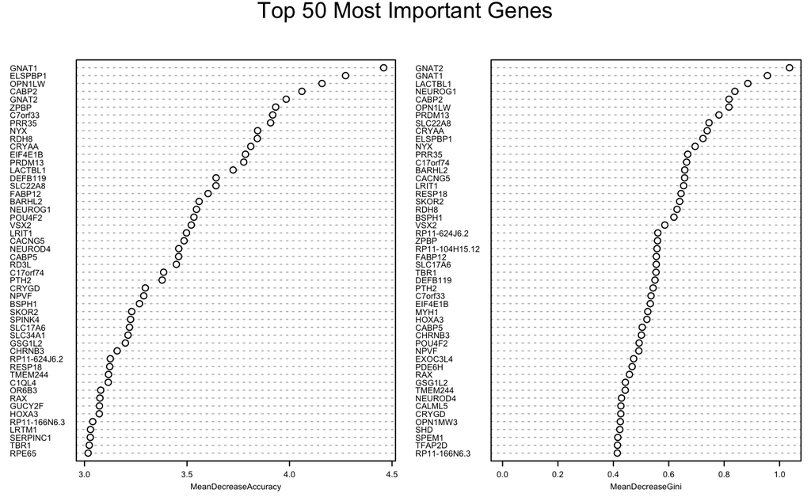

```r
varImpPlot(rf.retina.comp, scale = TRUE, n.var = 50, cex = 0.45, pt.cex = 0.75, main = "Top 50 Most Important Genes")
```

```r
impt.retina = importance(rf.retina.comp, scale = TRUE)
sum(impt.retina[, "MeanDecreaseAccuracy"] >= qnorm(0.95, mean = 0, sd = 1))
```

```
[1] 223
```

```r
genes.acc = impt.retina[order(impt.retina[, "MeanDecreaseAccuracy"], decreasing = TRUE), ][1:50, ]
genes.gini = impt.retina[order(impt.retina[, "MeanDecreaseGini"], decreasing = TRUE), ][1:50, ]
length(intersect(rownames(genes.acc), rownames(genes.gini)))
```

```
[1] 41
```

```r
sig.genes.list.retina = rownames(impt.retina)[which(impt.retina[, "MeanDecreaseAccuracy"] >= qnorm(0.95, mean = 0, sd = 1))]
write.table(sig.genes.list.retina, file = "~/Documents/git/unified_gene_expression/results/RF_MDA_sig_retina.txt",
            sep = "\n", row.names = F, col.names = F)
```